# Inleiding Statistiek

Bennett Kleinberg

Week 11

## Week 11

Verbanden tussen 2 variabelen

- Deel 1: Het idee van verbanden tussen variabelen
- Deel 2: Pearson correlatie
- Deel 3: Hypothese toetsing met de Pearson correlation

Deel 1: Het idee van relaties tussen variabelen

## Tot nu toe…

- keken we naar verschillen tussen groepen
- meer specifiek: gemiddelden-vergelijkingstesten (z-test, t-tests)
- gebruikelijke vorm: onafhankelijke variabele $\rightarrow$ afhankelijke variabele

We controleerden/manipuleerden de onafhankelijke variabele (bijv. extra lessen vs geen extra lessen)…

… en bekeken hoe dit de afhankelijke variabele beïnvloedde (b.v. statistiekcijfer)

## Maar!

- heel vaak werken we met observationele gegevens
- dit zijn gegevens waar we geen manipulatie of controle kunnen uitoefenen

In deze gevallen kijken we gewoon naar de relatie tussen variabelen.

## Soorten relaties

- beide variabelen op de verhoudings- of intervalschaal: **Pearson correlatie**
- beide variabelen op de ordinale schaal (rangen): **Spearman correlatie**
- één variabele op de verhoudings- of intervalschaal en één dichotome variabele: *puntsgewijze biseriële correlatie*
- twee dichotome variabelen: *Phi-coëfficiënt* (maar volgende week meer over de **Chi-kwadraattoets**)

## Voorbeeld

| participant | grade | hours |
| --- | --- | --- |
| 1 | 4.85 | 17.29 |
| 2 | 7.73 | 18.06 |
| 3 | 5.16 | 16.98 |
| 4 | 7.42 | 22.30 |
| 5 | 6.40 | 22.04 |
| 6 | 6.37 | 18.50 |
| 7 | 7.34 | 20.91 |
| 8 | 6.63 | 19.83 |
| 9 | 8.30 | 22.77 |
| 10 | 5.92 | 16.03 |

## In een figuur

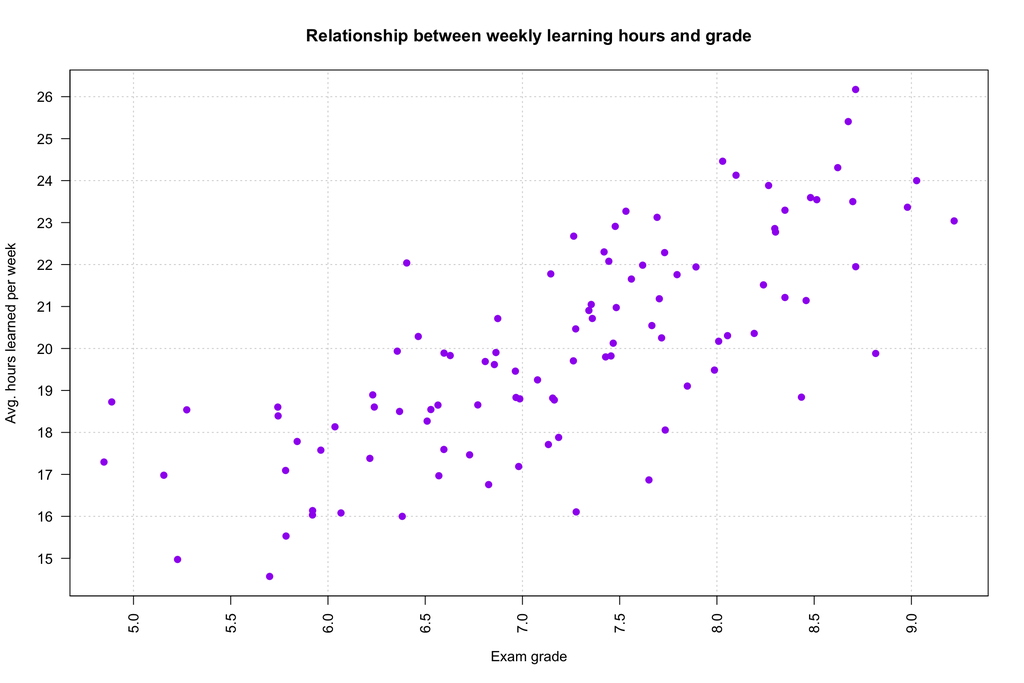

## Kenmerken

Elke relatie heeft:

- een **sterkte**
- een **richting** (positief, negatief)
- een **vorm** (lineair, kwadratisch, enz.)

## Zwakke positieve relatie

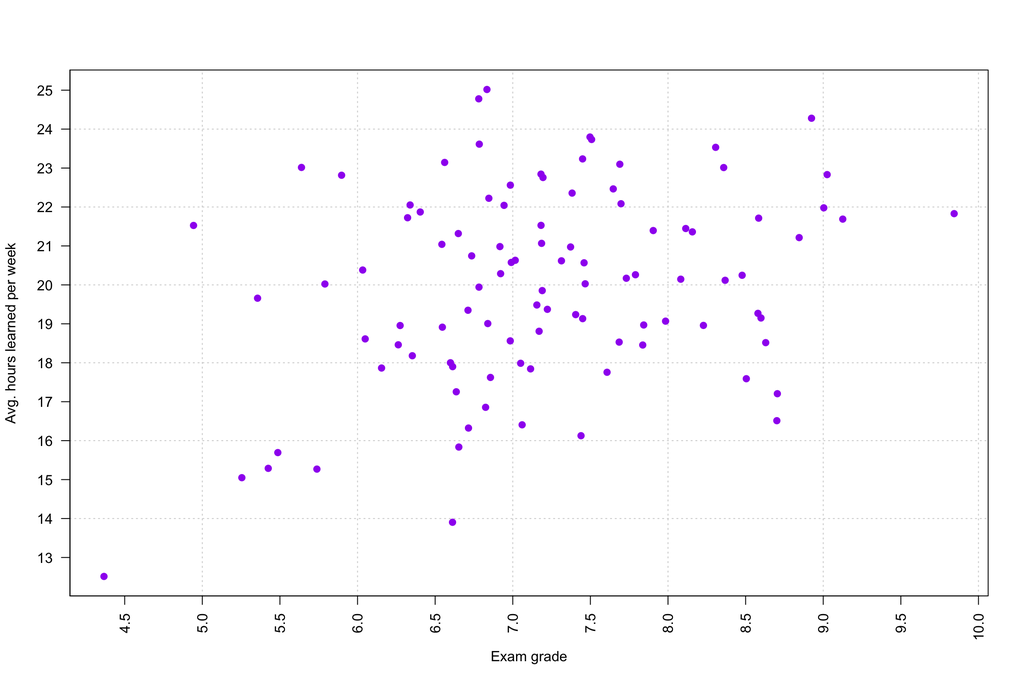

## Sterke positieve relatie

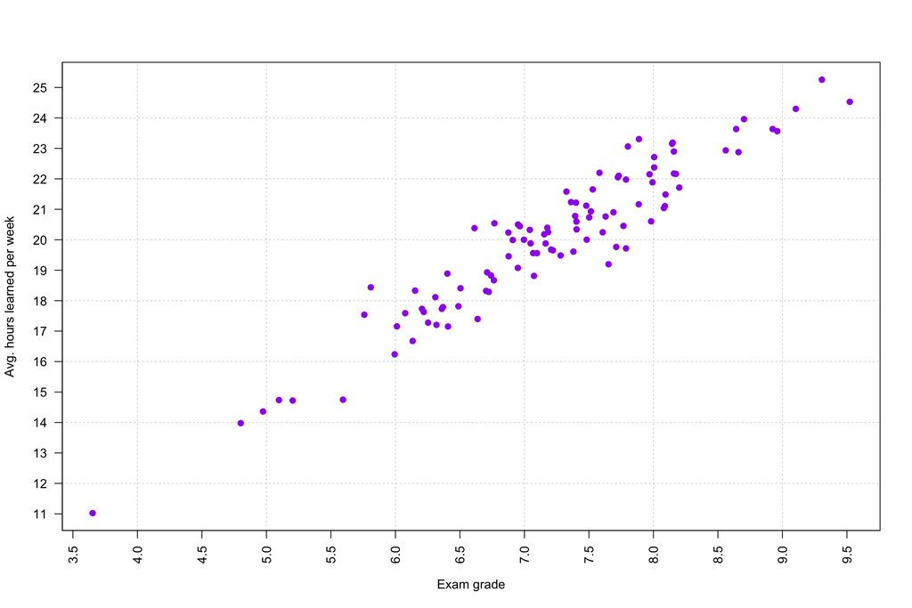

## Sterke negatieve relatie

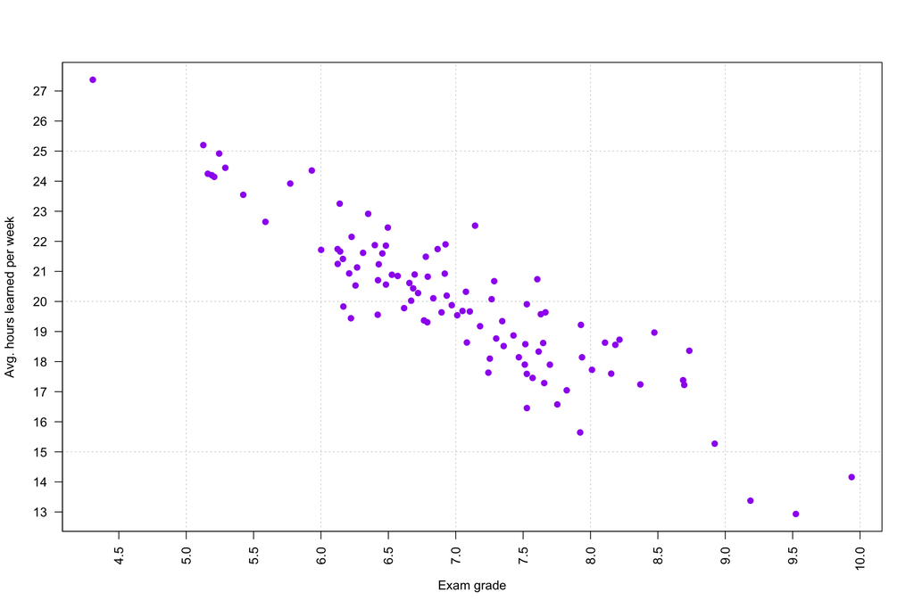

## Zwakke negatieve relatie

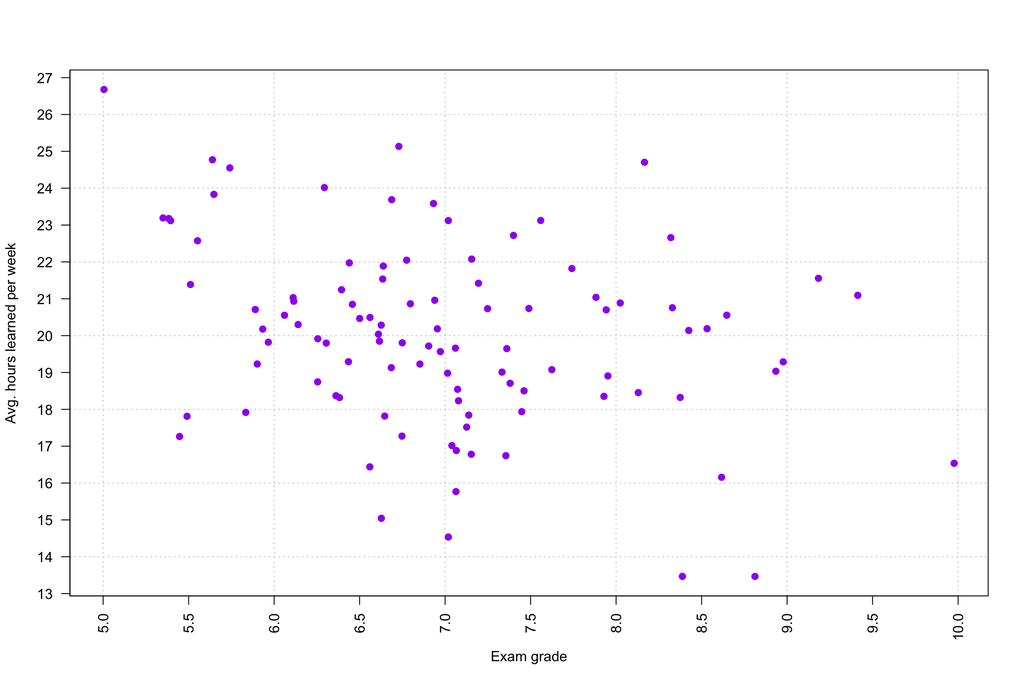

## Geen verband

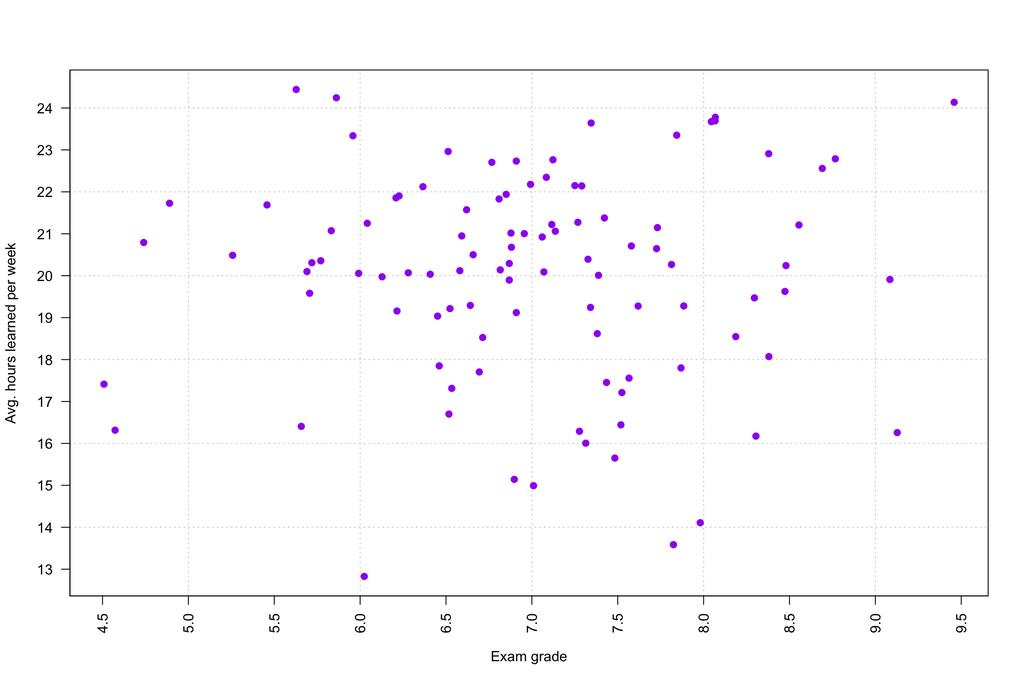

## Lineaire verbanden

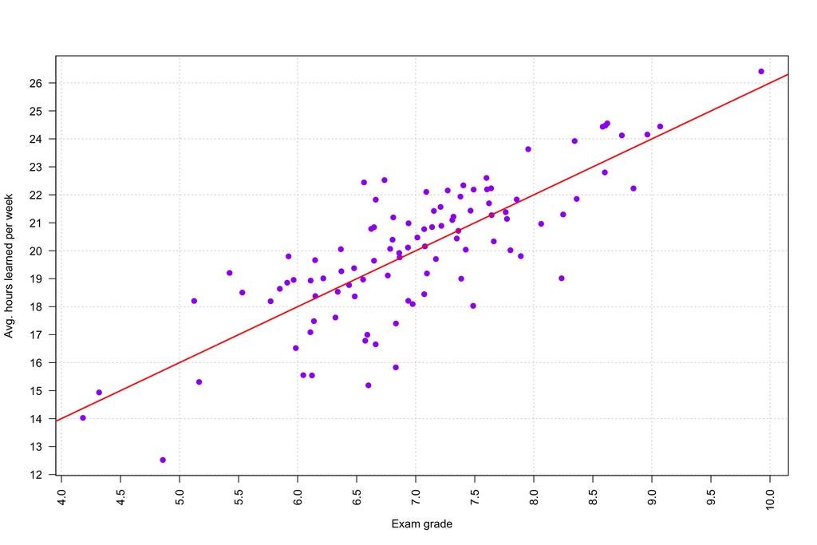

## What now?

- We willen verder gaan dan “eyeballing”.
- We hebben een numerieke maat van de correlatie nodig.
- We willen testen of de correlaties “significant verschillend van 0” zijn.

Deel 2: Pearson correlatie

## Kenmerken

- beschrijft het lineaire verband tussen twee variabelen
- geeft de sterkte van de relatie aan
- geeft de richting van het verband aan

De **correlatiecoëfficiënt** varieert van -1.00 tot +1.00.

## De correlatiecoëfficiënt

- notatie van de populatie: $\rho$ (Griekse letter “rho”)
- notatie van de steekproef: $r$
- effectgrootte: $R^2$
- negatieve waarden van $r \rightarrow$ negatief verband
- positieve waarden van $r \rightarrow$ positieve relatie
- waarden in de extremen (in de buurt van $\pm 1.00$) wijzen op sterkere verbanden
- waarden rond 0 wijzen op zwakke (of geen) relaties

## De correlatiecoëfficiënt

- twee variabelen $x$ en $y$
- als $x$ verandert, hoeveel verandert $y$ dan?

*Als we de verandering van $x$ kennen, is er dan een voorspelbare verandering in $y$?*

## Scatterplot

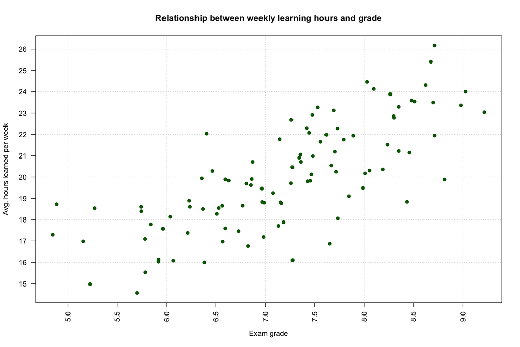

## Algemene logica

- voor een deel *variëren $x$ and $y$ samen*
- voor een deel *variëren $x$ and $y$ separaat*

$r = \frac{covariance}{variability\ of\ y\ and\ x\ separately}$

## Covariantie

Voor een populatie: $\sigma_{xy} = \frac{\sum{(x-\mu_x)(y-\mu_y)}}{N}$

Voor een steekproef: $s_{xy} = \frac{\sum{(x-M_x)(y-M_y)}}{n-1}$

## Mini voorbeeld

| participant | grade | hours |
| --- | --- | --- |
| 1 | 5 | 17 |
| 2 | 8 | 18 |
| 3 | 5 | 17 |
| 4 | 7 | 22 |
| 5 | 6 | 22 |

## Covariantie stap-voor-stap

1. Gemiddelden van de twee variabelen

$M_{grade} = 6.2$

$M_{hours} = 19.2$

## Covariantie stap-voor-stap

2. Afwijkingen

| participant | grade ($x$) | hours ($y$) | $x-M_x$ | $y-M_y$ |
| --- | --- | --- | --- | --- |
| 1 | 5 | 17 | -1.2 | -2.2 |
| 2 | 8 | 18 | 1.8 | -1.2 |
| 3 | 5 | 17 | -1.2 | -2.2 |
| 4 | 7 | 22 | 0.8 | 2.8 |
| 5 | 6 | 22 | -0.2 | 2.8 |

## Covariantie stap-voor-stap

3. Product van afwijkingen

| participant | grade ($x$) | hours ($y$) | $x-M_x$ | $y-M_y$ | $(x-M_x)(y-M_y)$ |
| --- | --- | --- | --- | --- | --- |
| 1 | 5 | 17 | -1.2 | -2.2 | 2.64 |
| 2 | 8 | 18 | 1.8 | -1.2 | -2.16 |
| 3 | 5 | 17 | -1.2 | -2.2 | 2.64 |
| 4 | 7 | 22 | 0.8 | 2.8 | 2.24 |
| 5 | 6 | 22 | -0.2 | 2.8 | -0.56 |

## Covariantie stap-voor-stap

4. Het verkrijgen van de som van producten van afwijkingen

Dit is $\sum{(x-M_x)(y-M_y)}$.

In het boek (blz. 490) wordt dit **SP** genoemd.

We verkrijgen:

$\sum{(x-M_x)(y-M_y)} = 2.64+(-2.16)+2.64+2.24+(-0.56) = 4.8$

## Covariantie stap-voor-stap

5. Delen door $N$ (populatie) of $n-1$ (steekproef)

We hebben een steekproef van $n=5$, dus:

$s_{xy} = \frac{\sum{(x-M_x)(y-M_y)}}{n-1} = \frac{4.8}{4} = 1.2$

De covariantie tussen $x$ (cijfer) en $y$ (uren) is 1.2.

Maar dit hangt af van de schaal van de data - hebben we geen gecorrigeerde versie van deze covariabiliteitswaarde?

## Van covariantie naar correlatie

We moeten deze covariantie corrigeren om een *dimensie-loze* metriek te verkrijgen.

Deze correctie gebeurt via de standaarddeviaties:

$s_{grade} = SD_{grade} = 1.30$

$s_{hours} = SD_{hours} = 2.59$

$r=\frac{s_{xy}}{s_x*s_y} = \frac{1.20}{1.30*2.59} = \frac{1.20}{3.37} = 0.36$

De correlatiecoëfficiënt $r$ wijst op een positief verband tussen het cijfer en de leertijd, $r=0.36$._

## Een alternatieve manier

In het boek wordt de formule als volgt gebruikt:

$r=\frac{SP}{\sqrt{SS_x*SS_y}}$

$SS_x = 6.8$ (grade)

$SS_y = 26.8$ (hours)

So: $r=\frac{SP}{\sqrt{SS_x*SS_y}}=\frac{4.8}{\sqrt{6.8*26.8}} = \frac{4.8}{13.59} = 0.36$

Identiek resultaat maar andere formule.

## Een effectgrootte voor $r$

Er is een eenvoudige manier om de *absolute grootte van het effect* uit te drukken:

we kwadrateren gewoon $r$ en krijgen $R^2$ (of $r^2$)

Hier: $R^2 = 0.36^2 = 0.13$

*13% van de variantie van het cijfer kan worden verklaard door (voorspeld met) het aantal geleerde uren (en omgekeerd!!)*

## Waar is het nuttig?

Correlatie lost een heleboel problemen op:

- kern van voorspellende modellering (regressie en uiteindelijk ook in AI)
- testen van ideeën (hebben mensen in extremistische gemeenschappen een lager IQ?)
- het beoordelen van de betrouwbaarheid van hertests (bijv. je typesnelheid twee keer testen)

## Valkuil

*Dit is een van de belangrijkste valkuilen in bijna al het onderzoek!*

**Correlatie impliceert geen causaal verband**

Onthoud dat altijd.

Het voorbeeld van ijs en criminaliteit.

Deel 3: Hypothese testen met de Pearson correlation

## Correlatie en hypothesen

We kunnen testen of een correlatie significant is.

Significant betekent hier: significant verschillend van 0.

Onze twee hypothesen zijn dan:

- $H_0: \rho=0$
- $H_1: \rho \neq 0$ (two-sided)
- $H_1: \rho>0$(one-sided)
- $H_1: \rho<0$(one-sided)

## Testen van $r$

We testen onze hypothese met de gekende structuur via de **t-statistiek**.

$t=\frac{samplewaarde - populatiewaarde}{standaardfout}$

We weten dat:

- steekproefwaarde = berekende (geobserveerde) $r$
- waarde van de populatie = $\rho$ (volgens $H_0$)

Hoe zit het met de SE?

## De standaardfout

$s_r = \sqrt{\frac{1-r^2}{n-2}}$

Dus:

$t = \frac{r-\rho}{s_r}$

## Ons voorbeeld

We hadden: $r=0.36$ voor $n=5$

$s_r = \sqrt{\frac{1-r^2}{n-2}}=\sqrt{\frac{1-0.36^2}{5-2}}=\sqrt{\frac{0.87}{3}} = 0.54$

$t = \frac{r-\rho}{s_r}=\frac{0.36-0}{0.54} = 0.67$

De kritieke t-waarde was voor $df=n-2 = 3$ –> 3.182 (tweestaartig voor $\alpha = .05$)

We kunnen de nulhypothese dus niet verwerpen. De correlatie is niet significant groter dan 0.

## Een ander voorbeeld

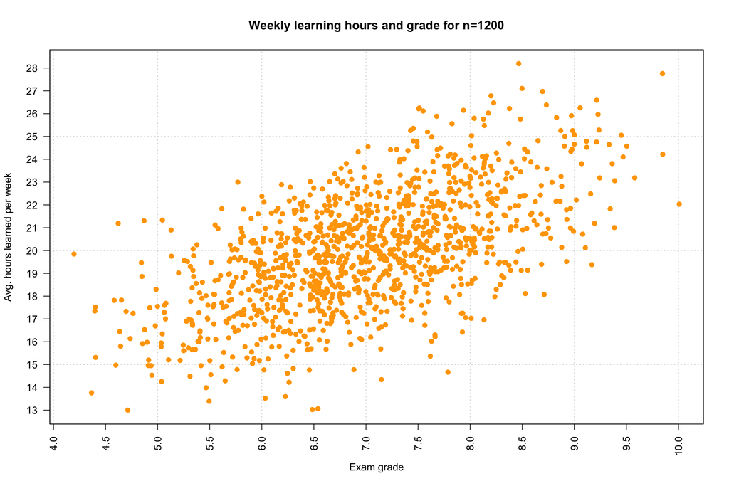

## Testen van de hypotheses

- We hebben data van $n=1200$ studenten en hun leertijd en statistiekcijfer.
- we gebruiken een $\alpha=.01$ voor de hypothese dat *meer leertijd leidt tot een hoger cijfer*

$H_0: \rho=0$ en $H_1: \rho>0$

Berekening van $r$ resulteert in $r=0.60$

## In de live sessie

- correlatie mini voorbeeld met de hand
- live studie over real-world correlaties

## Recap

- vaak willen we de relatie tussen twee variabelen beoordelen
- dit houdt in dat we geen manipulatie of controle kunnen gebruiken
- in plaats daarvan meten we de correlatie tussen deze variabelen
- de Pearson correlatie coëfficiënt geeft de sterkte en richting van een lineair verband aan

Als je correlaties wilt “raden”, hier is een spelletje: http://guessthecorrelation.com/_

## Volgende week

De Chi-kwadraat toets